# IODS course diary

Oskar Lappi

# Assignment 1: About the project

Here’s the link to the repo on github: https://github.com/oj-lappi/IODS-project

## My background and motivations

I’d like to learn about statistical tests and possibly how to add R to data pipelines.

I don’t think R will replace my current tools for analyzing and plotting data, but I do want to at least see how feasible it would be to add R as a tool for developing statistical analyses for experiments, and possibly writing some small programs for quick statistical analysis in postprocessing of experiments.

I’m familiar with *git*, it’s a daily driver for me, I tend to use gnuplot and python for quick plotting, and either use *python*, *UNIX* tools or custom *C++* programs for data analysis utilities.

## Goals

I’m interested in creating automatic data pipelines that process data in object storage and upload plots to a dashboard. R+Github pages might be a good way to do that, although I would prefer an on-prem solution (HU’s gitlab maybe?) or a self-hosted website.

## RStudio/Git integration

I have ssh keys set up on each of my computers, and a personal access token would be less flexible than that.

I can push and pull with this setup from RStudio.

## Exercises

I checked the exercises and followed some of them along locally, I think I’m getting the hang of it :).

```r
# Timestamp:

date()
```

```
## [1] "Tue Nov 21 00:58:01 2023"
```

# Assignment 2: Linear regression on the Learning2014 dataset

## 1. Reading the data

```r
#Dependencies
#install.packages(c("readr","lmtest", "dplyr"))
library(readr)
library(dplyr)
library(lmtest)
# Timestamp
date()
```

```
## [1] "Tue Nov 21 00:58:01 2023"
```

## 2. Analysis

```r
lrn2014 <- read_csv('data/learning2014.csv')
```

### 2.1 The shape of the data

```
## [1] "dimensions: 166" "dimensions: 7"
```

There are 166 rows with 7 columns each.

### 2.2 Descriptive statistics

#### Sex distribution

`gender` seems to be a categorical value, so let’s see the number of rows per `gender` (sex):

```
## # A tibble: 2 × 2
##   gender count
##   <chr>  <int>
## 1 F        110
## 2 M         56
```

110 F, and 56 M, there is a skew towards female students in the dataset. Let’s plot that.

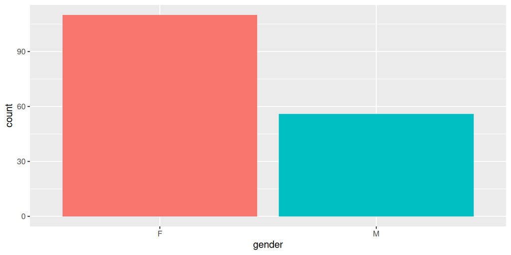

fig. 1.1, sex distributions

#### Age distribution

Let’s plot the age distribution of the students.

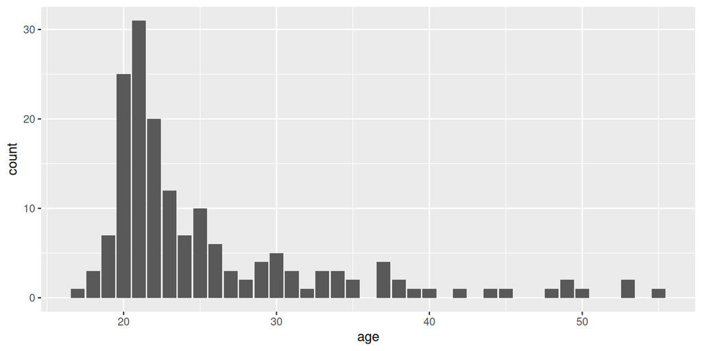

fig. 1.2, age distributions

```r
lrn2014 %>%
  ggplot(aes(x = age)) +
  stat_count()
```

```r
min(lrn2014$age)
```

```
## [1] 17
```

```r
max(lrn2014$age)
```

```
## [1] 55
```

```r
median(lrn2014$age)
```

```
## [1] 22
```

The age range is from 17 to 55, and the median is 22. Visually inspecting the distribution, the mode of the distribution is early twenties, as you would expect, although there is a long tail.

#### Age-sex distribution

Let’s combine the two columns into a classic population pyramid, or age-sex pyramid.

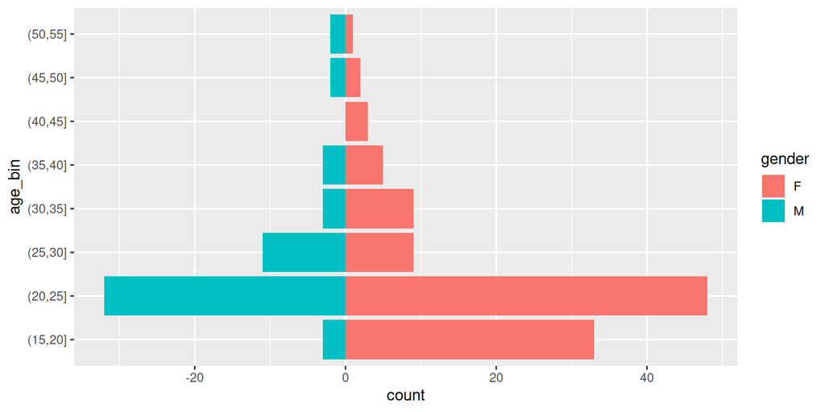

fig. 1.3a, population pyramid

```r
lrn2014 %>%
  mutate(age_bin = cut(age, breaks=seq(0,60,5))) %>% # Bin by age
  group_by(gender, age_bin) %>%                      # Group by bin and gender
  summarize(count =n()) %>%                          # Sum over groups
  mutate(count =
      if_else(gender == 'M', -count, count)) %>%     # Turn one negative
  ggplot(aes(x=count, y = age_bin)) +
  geom_col(aes(fill=gender))
```

There are very few male students under 20, I would speculate that this is due to Finnish army conscription, otherwise the distribution seems roughly equal on the female and male sides.

We can of course bin by year instead of 5 years, and we get a higher resolution but more noise.

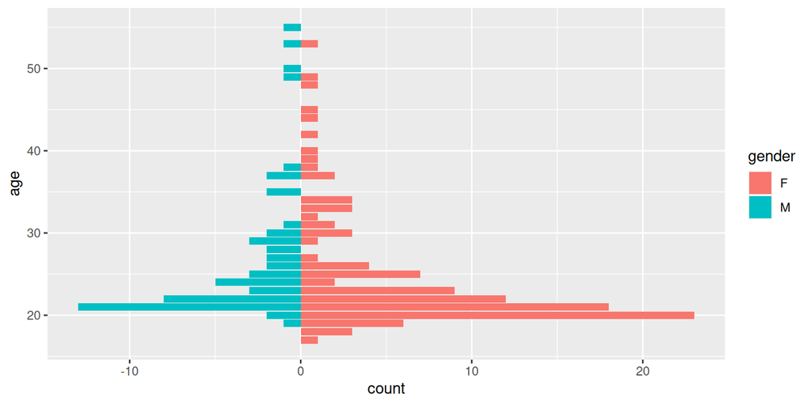

fig. 1.3b, population pyramid #2, fine-grained bins

There is one peculiar decline in the female student participation around ~26-28 which jumps back after thirty. This might be a maternity effect, but this is highly speculative, there’s very few samples in this dataset.

#### Exam scores

Let’s look at exam scores:

```r
paste("median:", median(lrn2014$points), ", mean:",mean(lrn2014$points), ", standard deviation:", sd(lrn2014$points))
```

```
## [1] "median: 23 , mean: 22.7168674698795 , standard deviation: 5.89488364245529"
```

Let’s look at the full distribution usin `geom_density`.

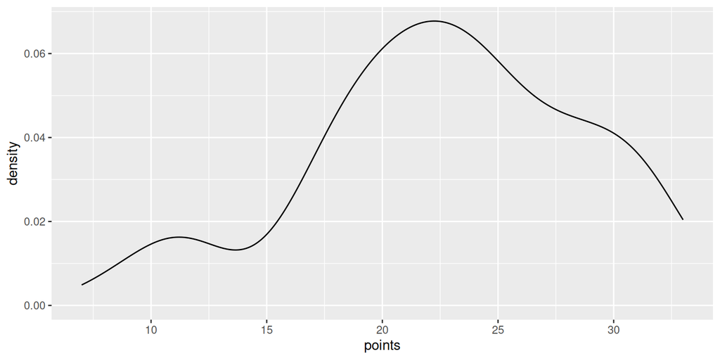

fig. 1.4a, exam score distribution

```r
lrn2014 %>%
  ggplot(aes(x=points)) +
  geom_density()
```

There’s a curious valley in the density at around 12-14 points. Let’s look closer.

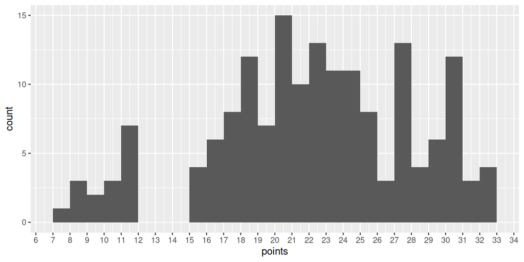

fig. 1.4b, exam score histogram

```r
lrn2014 %>%
  ggplot(aes(x=points, tickwidth=1)) +
  geom_histogram(boundary=0,binwidth=1) +
  scale_x_continuous(breaks = seq(0, 40, by = 1))
```

So no students got 12,13, or 14 points. The jump from 11 to 15 must be behind some barrier. Let’s look at our two demographic variables.

#### Exploring exam score distributions for different groups

##### Point means by sex, with age gradient

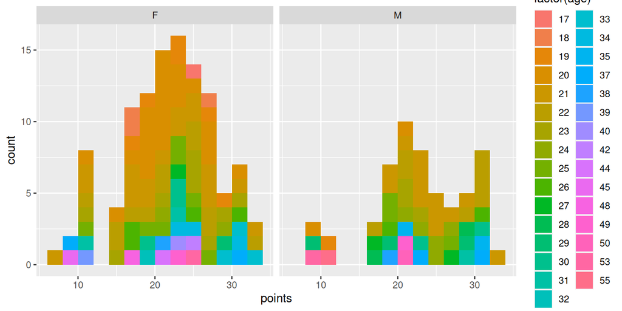

fig. 1.5a, exam scores by sex, with age gradient

```r
lrn2014 %>%
  group_by(gender) %>%
  ggplot(aes(x=points)) +
  geom_histogram(boundary=0,binwidth=2, aes(fill=factor(age))) +
  facet_wrap(~gender)
```

I see no clear bias either way, perhaps a slight correlation with score and age within the mode (20-30 years) and then no correlation for higher ages. The female distribution seems most well-behaved, although the gap from 11 points up is much sharper here as well.

##### Point means by age group, with sex

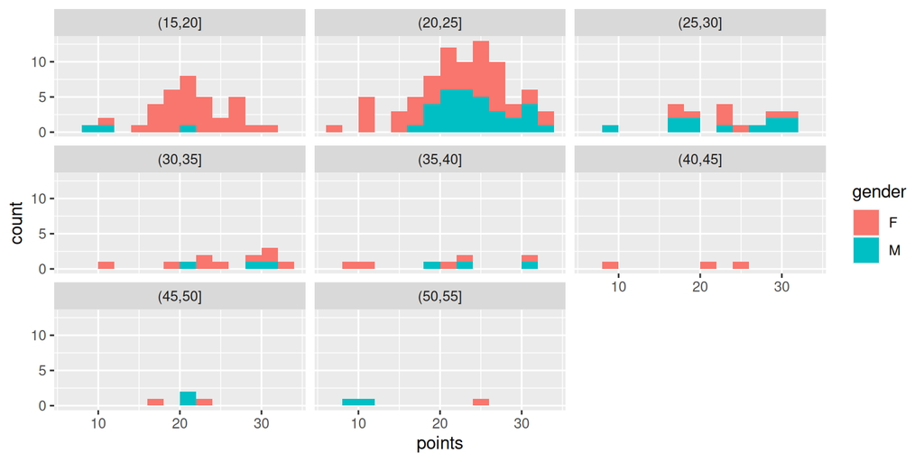

fig. 1.5b, exam scores by age group, with labeled sex

```r
lrn2014 %>%
  mutate(age_bin = cut(age, breaks=seq(0,60,5))) %>% # Bin by age
  group_by(gender, age_bin) %>%
  ggplot(aes(x=points)) +
  geom_histogram(boundary=0,binwidth=2, aes(fill=gender)) +
  facet_wrap(~age_bin)
```

##### Point means by age group, box plot

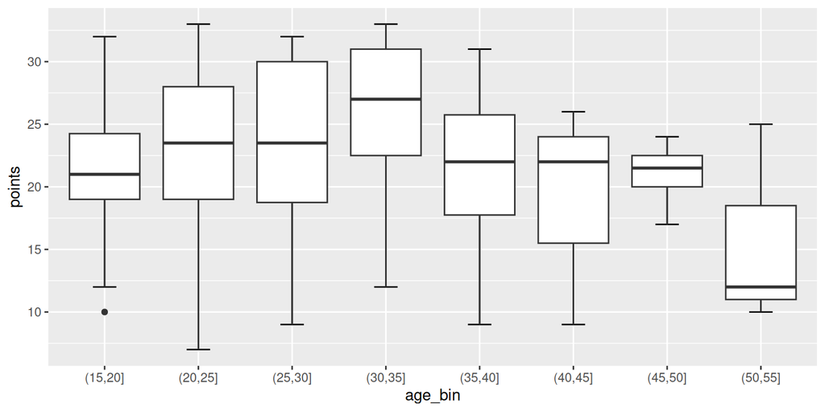

fig. 1.6a, exam score distributions by age group, box plot sequence

```r
lrn2014 %>%
  mutate(age_bin = cut(age, breaks=seq(0,60,5))) %>% # Bin by age
  ggplot(aes(x=age_bin, y = points)) +
  stat_boxplot(geom = "errorbar", width = 0.25) +
      geom_boxplot()
```

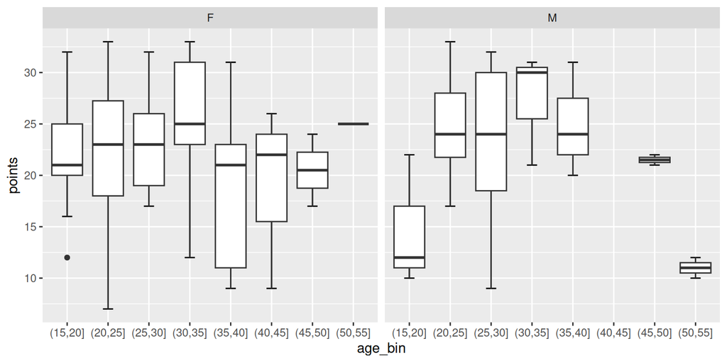

fig. 1.6b, exam score distributions by age-sex group, box plot sequence

```r
lrn2014 %>%
  mutate(age_bin = cut(age, breaks=seq(0,60,5))) %>% # Bin by age
  ggplot(aes(x=age_bin, y = points)) +
  stat_boxplot(geom = "errorbar", width = 0.25) +
      geom_boxplot()+
  facet_wrap(~gender)
```

I see no correlation between age and exam score in these plots.

### 2.3 Correlation matrix

Finally, let us look at all the survey question scores together with the already explored variables in a correlation matrix.

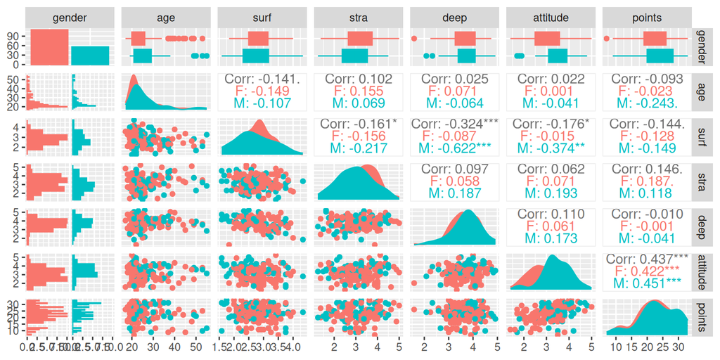

fig. 1.7, correlation matrix of all variables

```r
lrn2014 %>%
  select(gender, age, surf, stra, deep, attitude, points) %>%
  ggpairs(aes(fill=gender, color=gender),lower=list(combo=wrap("facethist",binwidth=0.5))) # Have to add the lower arg so ggpairs doesn't complain
```

And a possitive correlation between `points` and `attitude`! This is the strongest linear relationship in the data. And we can verify that age does not seem to have an effect at all.

## 3. Regression

Based on the data exploration, `attitude` seems the most likely candidate, and next after that: `stra` and `surf`.

### 3.1 Simple regression as baseline

Let’s start with a simple regression model of `points ~ attitude`, which will be our baseline.

```r
attitude_model <- lrn2014 %>%
                  lm(points ~ attitude, data = .)
summary(attitude_model)
```

```
##
## Call:
## lm(formula = points ~ attitude, data = .)
##
## Residuals:
##      Min       1Q   Median       3Q      Max
## -16.9763  -3.2119   0.4339   4.1534  10.6645
##
## Coefficients:
##             Estimate Std. Error t value Pr(>|t|)
## (Intercept)  11.6372     1.8303   6.358 1.95e-09 ***
## attitude      3.5255     0.5674   6.214 4.12e-09 ***
## ---
## Signif. codes:  0 '***' 0.001 '**' 0.01 '*' 0.05 '.' 0.1 ' ' 1
##
## Residual standard error: 5.32 on 164 degrees of freedom
## Multiple R-squared:  0.1906, Adjusted R-squared:  0.1856
## F-statistic: 38.61 on 1 and 164 DF,  p-value: 4.119e-09
```

There is clearly a statistically significant relationship between `attitude` and `points`. But R-squared is only around 18.5%, so there is a lot of variance not explained by the model.

### 3.2 Multiple regression, 3 variables

```r
three_var_model <- lrn2014 %>%
                  lm(points ~ attitude + stra + surf, data = .)
summary(three_var_model)
```

```
##
## Call:
## lm(formula = points ~ attitude + stra + surf, data = .)
##
## Residuals:
##      Min       1Q   Median       3Q      Max
## -17.1550  -3.4346   0.5156   3.6401  10.8952
##
## Coefficients:
##             Estimate Std. Error t value Pr(>|t|)
## (Intercept)  11.0171     3.6837   2.991  0.00322 **
## attitude      3.3952     0.5741   5.913 1.93e-08 ***
## stra          0.8531     0.5416   1.575  0.11716
## surf         -0.5861     0.8014  -0.731  0.46563
## ---
## Signif. codes:  0 '***' 0.001 '**' 0.01 '*' 0.05 '.' 0.1 ' ' 1
##
## Residual standard error: 5.296 on 162 degrees of freedom
## Multiple R-squared:  0.2074, Adjusted R-squared:  0.1927
## F-statistic: 14.13 on 3 and 162 DF,  p-value: 3.156e-08
```

The adjusted R-squared is higher, which means our model is capturing more of the underlying interactions than before, although still below 20%.

It seems that the relationship between `points` and `surf` is not statistically significant.

Let’s drop `surf` and keep `stra`, and try again.